# Question

Matrices $A$ and $B$ are defined below.

$$A = \begin{bmatrix}
3 & -9 & 8 & -3\\
4 & 6 & 9 & 5
\end{bmatrix}$$
$$B = \begin{bmatrix}
4 & 3 & 2\\
0 & -5 & -2\\
6 & 5 & 6\\
-7 & 0 & -1
\end{bmatrix}$$

Find the [product](https://en.wikipedia.org/wiki/Matrix_multiplication) $C=AB$.

$AB=$

[output not shown]

## Answerlist

- 27
- 35
- 45
- 75
- 81
- 94
- 27
- 35
- 45
- 75
- 81
- 94
- 27
- 35
- 45
- 75
- 81
- 94
- 27
- 35
- 45
- 75
- 81
- 94
- 27
- 35
- 45
- 75
- 81
- 94
- 27
- 35
- 45
- 75
- 81
- 94

# Solution

We wish to do matrix multiplication:

$$\begin{bmatrix}
3 & -9 & 8 & -3\\
4 & 6 & 9 & 5
\end{bmatrix}\begin{bmatrix}
4 & 3 & 2\\
0 & -5 & -2\\
6 & 5 & 6\\
-7 & 0 & -1
\end{bmatrix}$$

The product matrix has 2 rows and 3 columns.

To find the product matrix’s value in row 1 and column 1, sum the products of corresponding elements of row 1 in matrix A and column 1 in matrix B.
$$C_{[1,1]}=(3)(4)+(-9)(0)+(8)(6)+(-3)(-7)=81$$

To find the product matrix’s value in row 1 and column 2, sum the products of corresponding elements of row 1 in matrix A and column 2 in matrix B.
$$C_{[1,2]}=(3)(3)+(-9)(-5)+(8)(5)+(-3)(0)=94$$

To find the product matrix’s value in row 1 and column 3, sum the products of corresponding elements of row 1 in matrix A and column 3 in matrix B.
$$C_{[1,3]}=(3)(2)+(-9)(-2)+(8)(6)+(-3)(-1)=75$$

To find the product matrix’s value in row 2 and column 1, sum the products of corresponding elements of row 2 in matrix A and column 1 in matrix B.
$$C_{[2,1]}=(4)(4)+(6)(0)+(9)(6)+(5)(-7)=35$$

To find the product matrix’s value in row 2 and column 2, sum the products of corresponding elements of row 2 in matrix A and column 2 in matrix B.
$$C_{[2,2]}=(4)(3)+(6)(-5)+(9)(5)+(5)(0)=27$$

To find the product matrix’s value in row 2 and column 3, sum the products of corresponding elements of row 2 in matrix A and column 3 in matrix B.
$$C_{[2,3]}=(4)(2)+(6)(-2)+(9)(6)+(5)(-1)=45$$

All of that work leads to the answer:

$$C = AB = \begin{bmatrix}
81 & 94 & 75\\
35 & 27 & 45
\end{bmatrix}$$

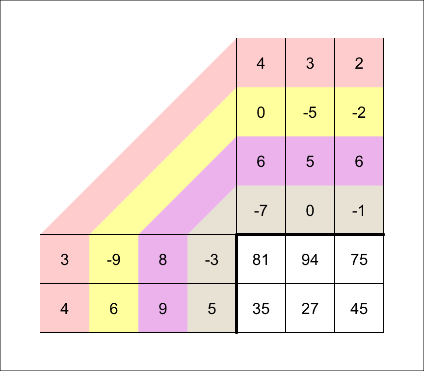

# Meta-information

extype: cloze exclozetype: schoice|schoice|schoice|schoice|schoice|schoice exsolution: 000010|010000|000001|100000|000100|001000 exname: mult_mats